# Car Sales Price Analysis

# 1. Problem Statement

Given dataset most of them are used cars so it opens the possibility to analyze features related to car sales.

[figure not shown]

## 1.1 Background Information

The Car Sale Advertisements dataset represents fresh and real life data.It contains data for more than 9.5K cars sale in Ukraine.

# 2. Loading Packages and Libraries

```r
library(tidyverse)
```

# 3. Data Profiling

## 3.1 Load dataset and Check the type of varibales

```r
car_df <- read.csv("car_sales.csv", header = T, stringsAsFactors = T)

str(car_df)
```

```
## 'data.frame':    9576 obs. of  10 variables:
##  $ car         : Factor w/ 87 levels "Acura","Alfa Romeo",..: 28 53 53 53 53 60 35 65 53 53 ...
##  $ price       : num  15500 20500 35000 17800 33000 16600 6500 10500 21500 22700 ...
##  $ body        : Factor w/ 6 levels "crossover","hatch",..: 1 4 3 6 5 1 4 5 4 4 ...
##  $ mileage     : int  68 173 135 162 91 83 199 185 146 125 ...
##  $ engV        : num  2.5 1.8 5.5 1.8 NA 2 2 1.5 1.8 2.2 ...
##  $ engType     : Factor w/ 4 levels "Diesel","Gas",..: 2 2 4 1 3 4 4 1 2 1 ...
##  $ registration: Factor w/ 2 levels "no","yes": 2 2 2 2 2 2 2 2 2 2 ...
##  $ year        : int  2010 2011 2008 2012 2013 2013 2003 2011 2012 2010 ...
##  $ model       : Factor w/ 888 levels "1 Series","1.3",..: 504 337 273 213 337 861 182 559 337 337 ...
##  $ drive       : Factor w/ 4 levels "","front","full",..: 3 4 4 2 1 3 2 2 4 4 ...
```

## 3.2 Content

Dataset contains 9576 rows and 10 variables with essential meanings:

car : manufacturer brand price : seller’s price in advertisement (in USD) body : car body type mileage : as mentioned in advertisement (’000 Km) engV : rounded engine volume (’000 cubic cm) engType : type of fuel (“Other” in this case should be treated as NA) registration: whether car registered in Ukraine or not year : year of production model : specific model name drive : drive type

## 3.3 Sample Data

```r
head(car_df)
```

|  | car | price | body | mileage | engV | engType | registration | year | model | drive |
| --- | --- | --- | --- | --- | --- | --- | --- | --- | --- | --- |
| 1 | Ford | 15500 | crossover | 68 | 2.5 | Gas | yes | 2010 | Kuga | full |
| 2 | Mercedes-Benz | 20500 | sedan | 173 | 1.8 | Gas | yes | 2011 | E-Class | rear |
| 3 | Mercedes-Benz | 35000 | other | 135 | 5.5 | Petrol | yes | 2008 | CL 550 | rear |
| 4 | Mercedes-Benz | 17800 | van | 162 | 1.8 | Diesel | yes | 2012 | B 180 | front |
| 5 | Mercedes-Benz | 33000 | vagon | 91 | NA | Other | yes | 2013 | E-Class |  |
| 6 | Nissan | 16600 | crossover | 83 | 2.0 | Petrol | yes | 2013 | X-Trail | full |

## 3.4 structure of the data

```r
glimpse(car_df)
```

```
## Observations: 9,576
## Variables: 10
## $ car          <fct> Ford, Mercedes-Benz, Mercedes-Benz, Mercedes-Benz...
## $ price        <dbl> 15500.00, 20500.00, 35000.00, 17800.00, 33000.00,...
## $ body         <fct> crossover, sedan, other, van, vagon, crossover, s...
## $ mileage      <int> 68, 173, 135, 162, 91, 83, 199, 185, 146, 125, 0,...
## $ engV         <dbl> 2.5, 1.8, 5.5, 1.8, NA, 2.0, 2.0, 1.5, 1.8, 2.2, ...
## $ engType      <fct> Gas, Gas, Petrol, Diesel, Other, Petrol, Petrol, ...
## $ registration <fct> yes, yes, yes, yes, yes, yes, yes, yes, yes, yes,...
## $ year         <int> 2010, 2011, 2008, 2012, 2013, 2013, 2003, 2011, 2...
## $ model        <fct> Kuga, E-Class, CL 550, B 180, E-Class, X-Trail, A...
## $ drive        <fct> full, rear, rear, front, , full, front, front, re...
```

## 3.5 Quick overview of dataset

```r
summary(car_df)
```

```
##             car           price               body         mileage
##  Volkswagen   : 936   Min.   :     0   crossover:2069   Min.   :  0.0
##  Mercedes-Benz: 921   1st Qu.:  4999   hatch    :1252   1st Qu.: 70.0
##  BMW          : 694   Median :  9200   other    : 838   Median :128.0
##  Toyota       : 541   Mean   : 15633   sedan    :3646   Mean   :138.9
##  VAZ          : 489   3rd Qu.: 16700   vagon    : 722   3rd Qu.:194.0
##  Renault      : 469   Max.   :547800   van      :1049   Max.   :999.0
##  (Other)      :5526
##       engV          engType     registration      year
##  Min.   : 0.100   Diesel:3013   no : 561     Min.   :1953
##  1st Qu.: 1.600   Gas   :1722   yes:9015     1st Qu.:2004
##  Median : 2.000   Other : 462                Median :2008
##  Mean   : 2.646   Petrol:4379                Mean   :2007
##  3rd Qu.: 2.500                              3rd Qu.:2012
##  Max.   :99.990                              Max.   :2016
##  NA's   :434
##         model        drive
##  E-Class   : 199        : 511
##  A6        : 172   front:5188
##  Camry     : 134   full :2500
##  Vito Ã¯Ã Ã±Ã±.: 131   rear :1377
##  Lanos     : 127
##  X5        : 119
##  (Other)   :8694
```

# 4 Data Normalization

## 4.1 Remove new cars

```r
df <- car_df %>%
      mutate(price = price/1000, # price in '000
             age = as.numeric(format(Sys.Date(), "%Y")) - year, # age
             annualRun = mileage/age) %>%
      filter(age != 0) # remove new cars
```

# 5. Study Questions

- **Which car has the biggest average annual mileage? And what about average age?**
- **What is the distribution of year of production?**
- **What about petrol and body type? Do they influence drivers mileage?**
- **What is the distribution of engine volume?**

# 6. Analyze Through Study Questions

## 6.1 Which car has the biggest average annual mileage? And what about average age?

```r
TopByProd <- df %>%
      group_by(car) %>%
      summarise(carNum = n(), medianRun = round(median(annualRun), 1), meanRun = round(mean(age), 1)) %>%
      arrange(desc(carNum)) %>%
      as.data.frame()
head(TopByProd, 20)
```

|  | car | carNum | medianRun | meanRun |
| --- | --- | --- | --- | --- |
| 1 | Volkswagen | 936 | 14.0 | 12.4 |
| 2 | Mercedes-Benz | 921 | 13.1 | 12.6 |
| 3 | BMW | 694 | 12.5 | 13.7 |
| 4 | Toyota | 541 | 10.9 | 10.5 |
| 5 | VAZ | 489 | 7.4 | 18.6 |
| 6 | Renault | 469 | 15.0 | 10.7 |
| 7 | Audi | 457 | 12.8 | 14.2 |
| 8 | Opel | 400 | 13.1 | 16.5 |
| 9 | Nissan | 368 | 9.0 | 10.7 |
| 10 | Skoda | 368 | 12.5 | 10.1 |

[output cut: 10 more lines]

It seems that VAZ (Soviet/Russian car manufacturer) has much lower annual mileage than other popular producers. On the other hand it has the biggest age in average. It is obvious that annual mileage falls while car is getting older. But let’s check.

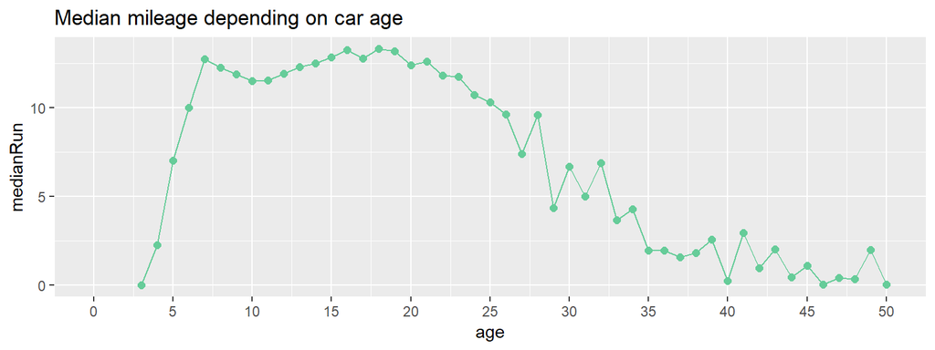

```r
runByAge <- df %>%
      group_by(age) %>%
      summarise(carNum = n(), medianRun = median(annualRun), meanRun = mean(annualRun))

ggplot(runByAge, aes(x = age, y = medianRun)) + geom_line(colour = "#66CC99") +
      geom_point(colour = "#66CC99", size = 2) +
      scale_x_continuous(breaks=seq(0, 50, 5), limits= c(0, 50)) +
      ggtitle("Median mileage depending on car age")
```

```r
df <- mutate(df, ageGroup = ifelse(age<= 3, "a(<=3)",
                                   ifelse(3 < age & age <= 6, "b(4-6)",
                                          ifelse(5 < age & age <= 10, "c(7-10)",
                                                 ifelse(10 < age & age <= 15, "d(11-15)",
                                                        ifelse(15 < age & age <= 20, "e(16-20)",
                                                               ifelse(20 < age & age <= 30, "f(21-30)",
                                                                      "g(30+)")))))))
df$ageGroup <- as.factor(df$ageGroup)
df <- arrange(df, ageGroup)
table(df$ageGroup)
```

```
##
##   a(<=3)   b(4-6)  c(7-10) d(11-15) e(16-20) f(21-30)   g(30+)
##      459     1268     2204     3403     1108      860      274
```

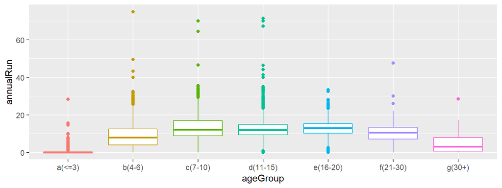

```r
ggplot(df, aes(x = ageGroup, y = annualRun, color = ageGroup)) +
      geom_boxplot() + ylim(0, 75) + theme(legend.position = "none")
```

As we see average values of mileage for VAZ are lower than 2nd quartile for all cars of this age. In this cars it is easy to “adjust” speedometer readings. And assumed that we got evidence of such massive manipulations.

## 6.2 What is the distrubution of year of production?

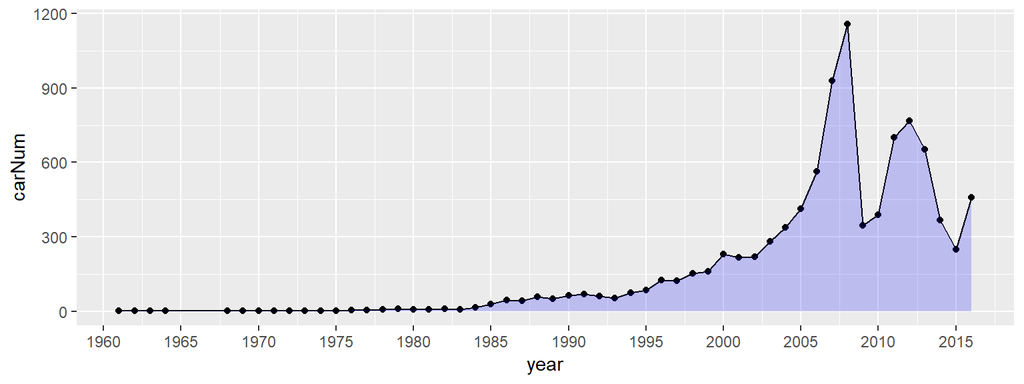

```r
ageDistr <- df %>%
      group_by(age, year) %>%
      summarise(carNum = n()) %>%
      arrange(age) %>%
      as.data.frame()

ageDistr %>%
      filter(year > 1960) %>%
      ggplot(aes(x = year, y = carNum)) + geom_line() + geom_point() +
      geom_area(fill = "blue", alpha = .2) + scale_x_continuous(breaks=seq(1960, 2015, 5))
```

There are two clear groups. The first one is relevant to post Soviet period growth with a burst after 2000. The second one is short recovery after 2008 crisis.

It is interesting what are the oldest cars at the market.

```r
oldest <- df %>%
      group_by(car, model) %>%
      summarise(carNum = n(), AVyear = round(mean(year),0)) %>%
      arrange(AVyear) %>%
      as.data.frame()
head(oldest, 20)
```

|  | car | model | carNum | AVyear |
| --- | --- | --- | --- | --- |
| 1 | Moskvich-AZLK | 401 | 1 | 1953 |
| 2 | GAZ | 69 | 2 | 1960 |
| 3 | ZAZ | 965 | 1 | 1961 |
| 4 | Moskvich-AZLK | 403 | 1 | 1964 |
| 5 | GAZ | 21 | 9 | 1965 |
| 6 | Moskvich-AZLK | 412 | 1 | 1971 |
| 7 | Mercedes-Benz | S 280 | 2 | 1974 |
| 8 | Ford | Granada | 2 | 1978 |
| 9 | UAZ | 452 ïÃ ññ. | 1 | 1978 |
| 10 | Opel | Manta | 1 | 1979 |

[output cut: 10 more lines]

Mainly it is Soviet classics but at the same time you can buy stylish coupe Opel Manta from 1979!

## 6.3 What about petrol and body type? Do they influence drivers mileage?

```r
RunByEngine <- df[which(df$body != "van"),] %>%
      group_by(engType) %>%
      summarise(carNum = n(), medianRun = round(median(annualRun), 1),
                meanRun = round(mean(annualRun), 1), avAge = round(mean(age), 1)) %>%
      arrange(desc(carNum)) %>%
      as.data.frame()
RunByEngine
```

| engType | carNum | medianRun | meanRun | avAge |
| --- | --- | --- | --- | --- |
| Petrol | 4310 | 9.6 | 9.5 | 12.4 |
| Diesel | 2116 | 13.3 | 12.7 | 10.9 |
| Gas | 1666 | 11.5 | 11.6 | 14.7 |
| Other | 435 | 8.3 | 8.8 | 12.0 |

Excluded vans because they are mainly diesels and are often used as commercial transport. Anyway we see Diesel engines have consistently bigger annual mileage. Though they are some younger than other types. Let’s check distributions.

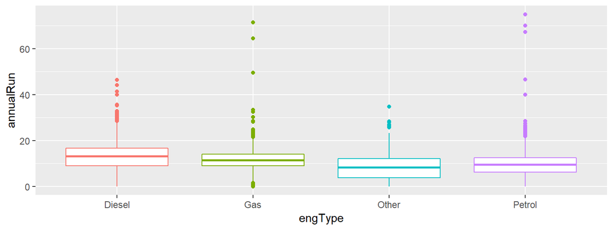

```r
ggplot(df[which(df$body != "van"),], aes(x = engType, y = annualRun, color = engType)) +
      geom_boxplot() + ylim(0, 75) + theme(legend.position = "none")
```

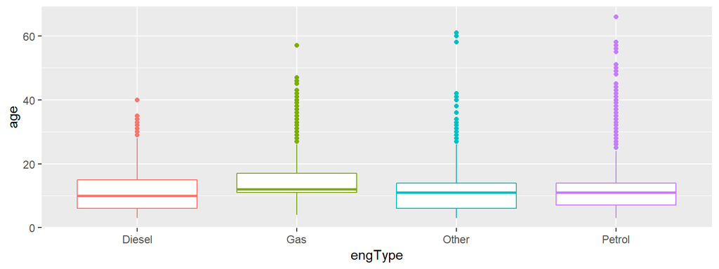

```r
ggplot(df[which(df$body != "van"),], aes(x = engType, y = age, color = engType)) +
      geom_boxplot() + theme(legend.position = "none")
```

If you want you can check statistical significance between annual mileage of Diesel cars and others. But it looks like Diesel drivers are indeed tend to drive more. Also we can see that the cars which use gas as a fuel are mainly old ones. And it is clear because often people install gas equipment at old voracious petrol cars.

## 6.4 What is the distribution of engine volume?

First of all general distribution.

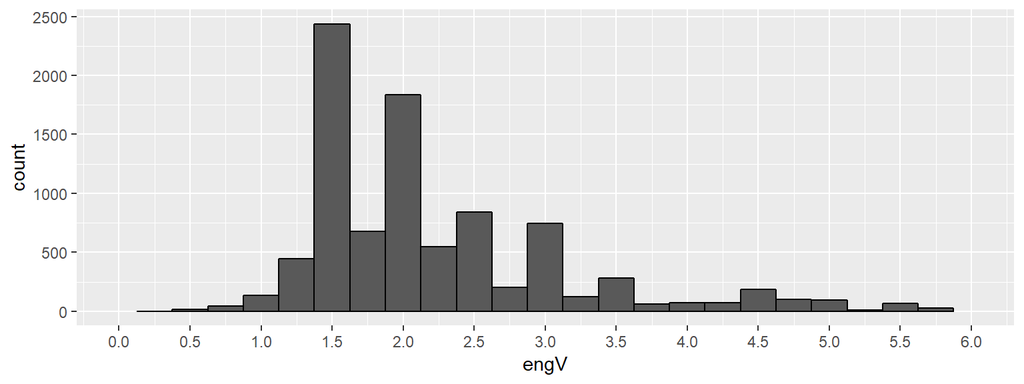

```r
df %>%
      ggplot(aes(x = engV)) + geom_histogram(binwidth=.25, colour="black") +
      scale_x_continuous(breaks=seq(0, 6, 0.5), limits= c(0, 6))
```

Main engine volumes are clear to understand, the most popular one is 1.5-1.6 litres. Does the pattern differ across different engine types? Let’s see.

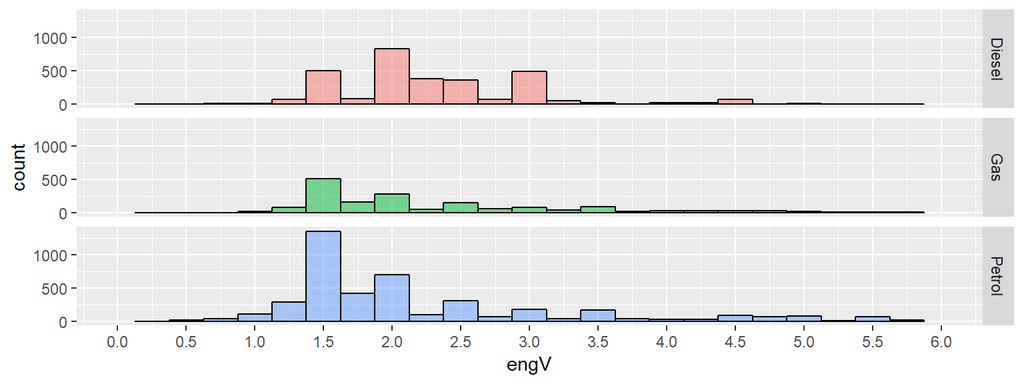

```r
df %>%
      filter(engType != "Other") %>%
      ggplot(aes(x=engV, fill = engType)) +
      geom_histogram(binwidth=.25, alpha=.5, colour="black", position="identity") +
      scale_x_continuous(breaks=seq(0, 6, 0.5), limits= c(0, 6)) +
      facet_grid(engType ~ .) + theme(legend.position = "none")
```

Indeed main part of diesel engines has 2l volume, while petrol as usual is just 1.5l. Gas engines have the same pattern as petrol because again they are just reworked petrol ones.

It is also interesting to take a look at body type and engine volume relation.

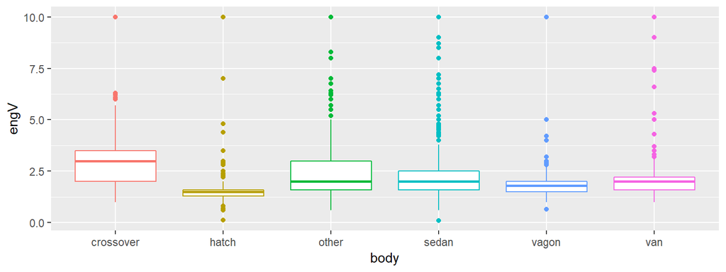

```r
ggplot(df, aes(x = body, y = engV, color = body)) + geom_boxplot() +
      theme(legend.position = "none")
```

Hatchbacks almost don’t have variance - their engines gathered in 1.4-1.6 litters zone. Almost the same with vagons which often have 2l volume. While crossover engine volume can vary significantly.

Let’s glance at the number of offers by body type. Found sedan is the most popular.

```r
df %>%
      group_by(body) %>%
      summarise(count = n()) %>%
      arrange(desc(count)) %>%
      as.data.frame()
```

| body | count |
| --- | --- |
| sedan | 3646 |
| crossover | 2069 |
| hatch | 1252 |
| van | 1049 |
| other | 838 |
| vagon | 722 |

# 7. Final Analysis

The sales analysis also showed that people preferred a sedan with petrol engine.

This shows that the company should produce petrol sedan to increase their chances of making profit.